# PROJECT 4

# EDA: Red Wine by Deependra Nimiwal

# About

In this exercise, I will explore a data set on wine quality and physicochemical properties. The objective is to explore which chemical properties influence the quality of red wines. I’ll start by exploring the data using the statistical program, R. As interesting relationships in the data are discovered, I’ll produce and refine plots to illustrate them. The data is available for download here and background information is available at this link. https://docs.google.com/document/d/1qEcwltBMlRYZT-l699-71TzInWfk4W9q5rTCSvDVMpc/pub?embedded=true

# Summary Statistics

```
## 'data.frame':    1599 obs. of  13 variables:
##  $ X                   : int  1 2 3 4 5 6 7 8 9 10 ...
##  $ fixed.acidity       : num  7.4 7.8 7.8 11.2 7.4 7.4 7.9 7.3 7.8 7.5 ...
##  $ volatile.acidity    : num  0.7 0.88 0.76 0.28 0.7 0.66 0.6 0.65 0.58 0.5 ...
##  $ citric.acid         : num  0 0 0.04 0.56 0 0 0.06 0 0.02 0.36 ...
##  $ residual.sugar      : num  1.9 2.6 2.3 1.9 1.9 1.8 1.6 1.2 2 6.1 ...
##  $ chlorides           : num  0.076 0.098 0.092 0.075 0.076 0.075 0.069 0.065 0.073 0.071 ...
##  $ free.sulfur.dioxide : num  11 25 15 17 11 13 15 15 9 17 ...
##  $ total.sulfur.dioxide: num  34 67 54 60 34 40 59 21 18 102 ...
##  $ density             : num  0.998 0.997 0.997 0.998 0.998 ...
##  $ pH                  : num  3.51 3.2 3.26 3.16 3.51 3.51 3.3 3.39 3.36 3.35 ...
##  $ sulphates           : num  0.56 0.68 0.65 0.58 0.56 0.56 0.46 0.47 0.57 0.8 ...
##  $ alcohol             : num  9.4 9.8 9.8 9.8 9.4 9.4 9.4 10 9.5 10.5 ...
##  $ quality             : int  5 5 5 6 5 5 5 7 7 5 ...
```

```
##        X          fixed.acidity   volatile.acidity  citric.acid
##  Min.   :   1.0   Min.   : 4.60   Min.   :0.1200   Min.   :0.000
##  1st Qu.: 400.5   1st Qu.: 7.10   1st Qu.:0.3900   1st Qu.:0.090
##  Median : 800.0   Median : 7.90   Median :0.5200   Median :0.260
##  Mean   : 800.0   Mean   : 8.32   Mean   :0.5278   Mean   :0.271
##  3rd Qu.:1199.5   3rd Qu.: 9.20   3rd Qu.:0.6400   3rd Qu.:0.420
##  Max.   :1599.0   Max.   :15.90   Max.   :1.5800   Max.   :1.000
##  residual.sugar     chlorides       free.sulfur.dioxide
##  Min.   : 0.900   Min.   :0.01200   Min.   : 1.00
##  1st Qu.: 1.900   1st Qu.:0.07000   1st Qu.: 7.00
##  Median : 2.200   Median :0.07900   Median :14.00
##  Mean   : 2.539   Mean   :0.08747   Mean   :15.87
##  3rd Qu.: 2.600   3rd Qu.:0.09000   3rd Qu.:21.00
##  Max.   :15.500   Max.   :0.61100   Max.   :72.00
##  total.sulfur.dioxide    density             pH          sulphates
##  Min.   :  6.00       Min.   :0.9901   Min.   :2.740   Min.   :0.3300
##  1st Qu.: 22.00       1st Qu.:0.9956   1st Qu.:3.210   1st Qu.:0.5500
##  Median : 38.00       Median :0.9968   Median :3.310   Median :0.6200
##  Mean   : 46.47       Mean   :0.9967   Mean   :3.311   Mean   :0.6581
##  3rd Qu.: 62.00       3rd Qu.:0.9978   3rd Qu.:3.400   3rd Qu.:0.7300
##  Max.   :289.00       Max.   :1.0037   Max.   :4.010   Max.   :2.0000
##     alcohol         quality
##  Min.   : 8.40   Min.   :3.000
##  1st Qu.: 9.50   1st Qu.:5.000
##  Median :10.20   Median :6.000
##  Mean   :10.42   Mean   :5.636
##  3rd Qu.:11.10   3rd Qu.:6.000
##  Max.   :14.90   Max.   :8.000
```

Some Initial Points:-

1. We have 1599 observations of 13 variables.
2. Quality of Wine Ranges from 3 to 8. (3 being worst, 8 being best)
3. Outliers found in fixed.acidity, volatile.acidity, citric.acid, residual.sugar, free.sulfur.dioxide, total.sulfur.dioxide.
4. Irregularties found in chlorides data (Maximum Value).
5. Is there any relation between free.sulfur.dioxide and total.sulfur.dioxide ?
6. Is there any relation between fixed.acidity and volatile.acidity ?

# A. Univariate Plots Section

Let us first analyze each variable individually to get an overview.

## A.1 Fixed Acidity

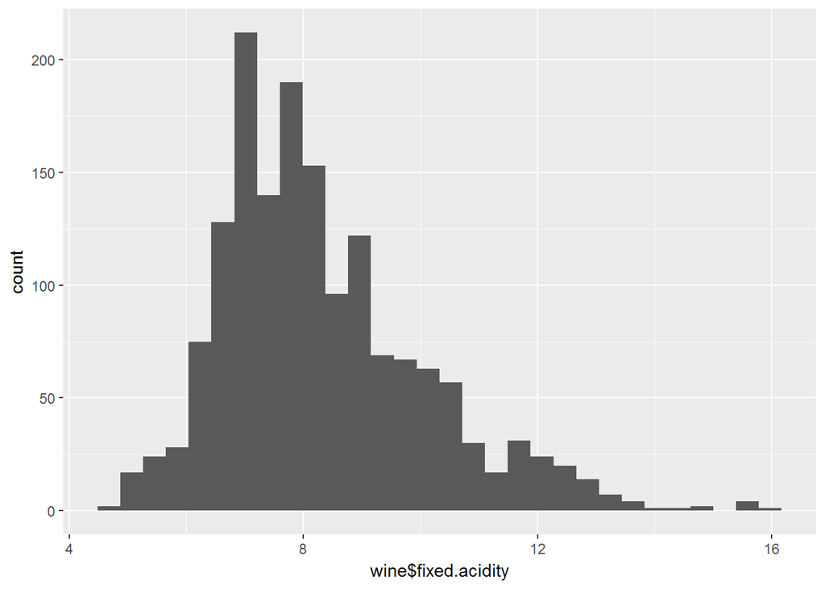

```
##    Min. 1st Qu.  Median    Mean 3rd Qu.    Max.
##   6.100   7.525   8.950   8.950  10.380  11.800
```

## A.2 Volatile Acidity

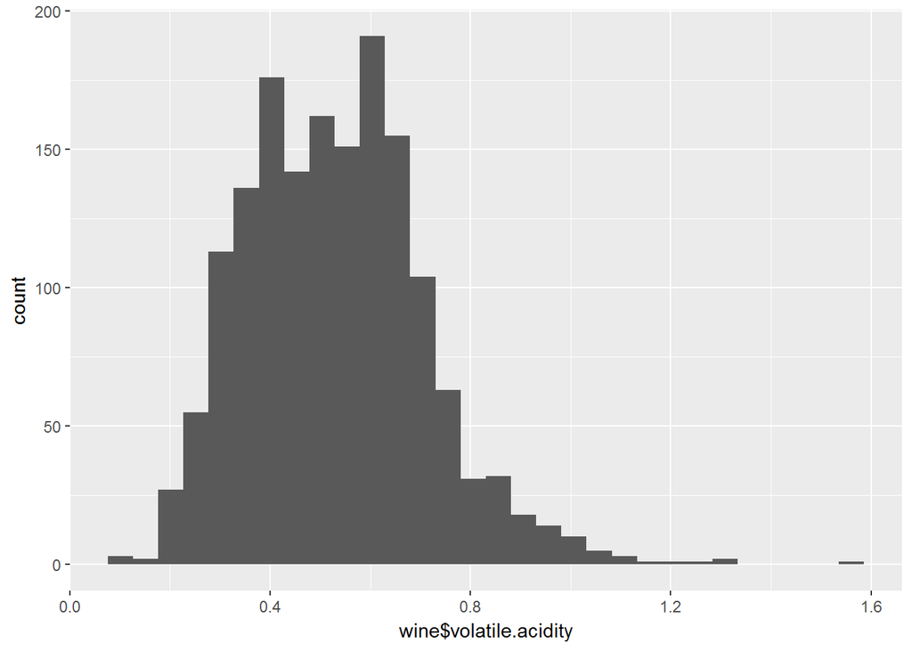

Volatile Acidity ranges from 0.12 to 1.58. We can clearly see outliers here. We can see how 90% of the data exist between 0.27 to 0.84 respectively.

```
##    Min. 1st Qu.  Median    Mean 3rd Qu.    Max.
##  0.2700  0.4125  0.5550  0.5550  0.6975  0.8400
```

## A.3 Citric Acid

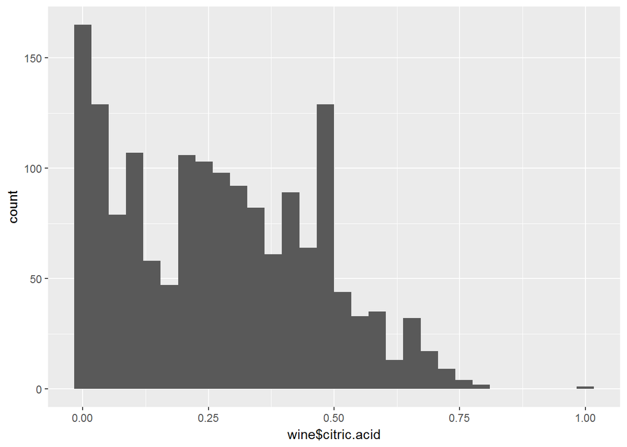

Citric Acid ranges from 0 to 1. We can see some values are in 0 range and the plot is little positively skewed. Let us normalize this plot and remove outliers.

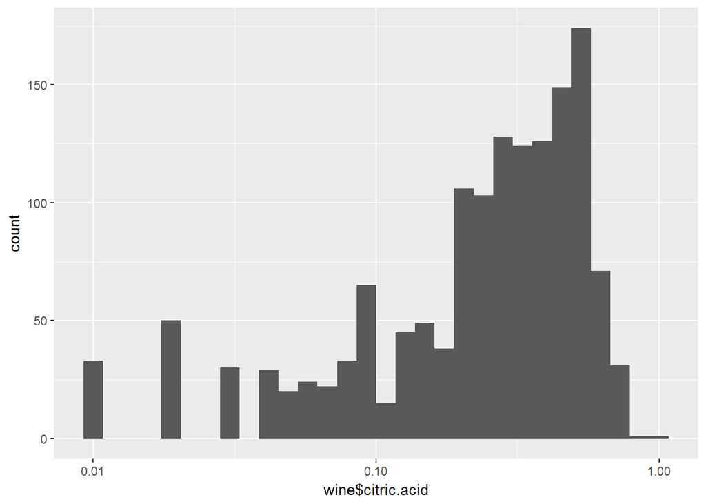

After using scale_x_log10 function, We notice 132 observations containing 0 values in citric acid. The above plot has removed these zero values. It could be genuine data or some error.

## A.4 Residual Sugar

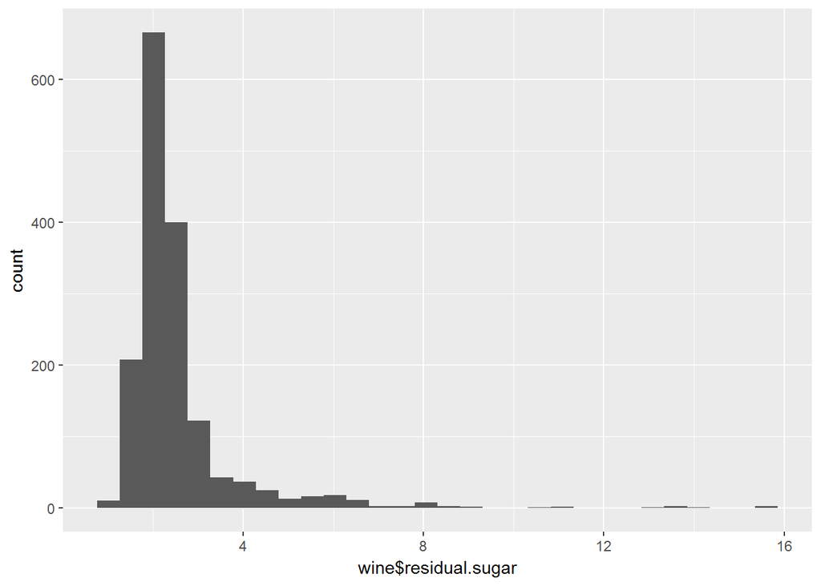

We see huge outliers in residual sugar. Let us remove these outliers.

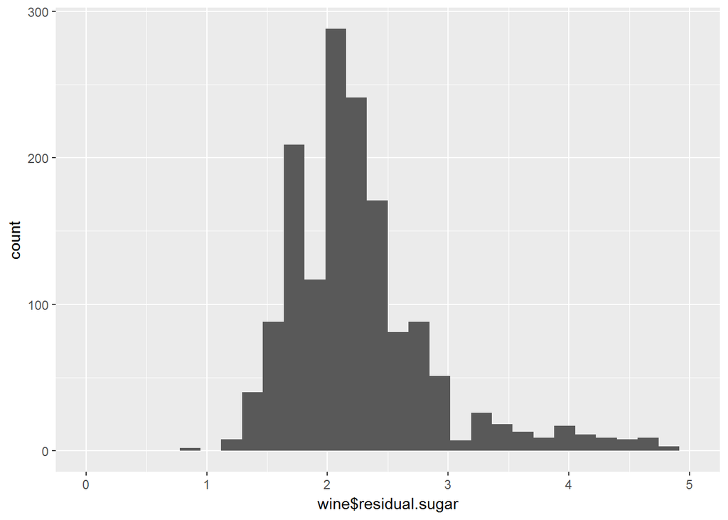

We used scale_x_log10 to remove the outliers. The new plot looks normally distributed, Below summary shows how 90% residual sugar exist between 1.6 and 5.1. This means there are huge outliers in residual sugar.

```
##    Min. 1st Qu.  Median    Mean 3rd Qu.    Max.
##   1.590   2.468   3.345   3.345   4.222   5.100
```

## A.5 Chlorides

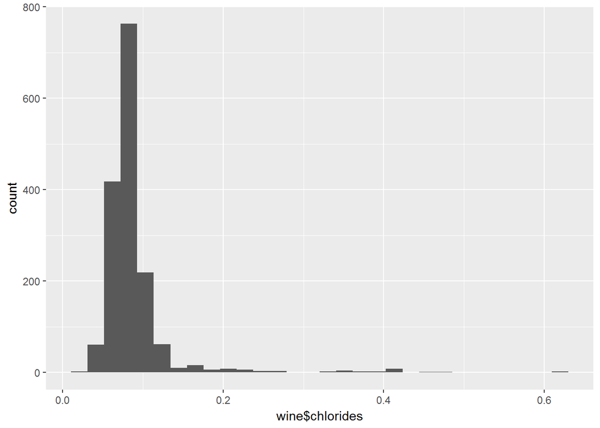

We also see huge outliers in chlorides. Let us remove these outliers.

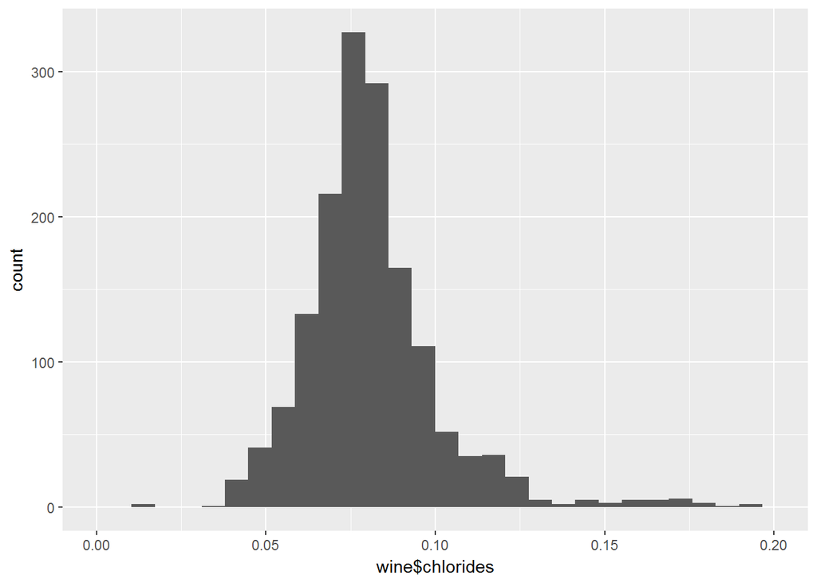

We used scale_x_log10 function to remove outliers. From above plot and below summary, we can see 90% percent of chloride exist between 0.054 and 0.126, where total range is between 0.012 and 0.61.

```
##    Min. 1st Qu.  Median    Mean 3rd Qu.    Max.
## 0.05400 0.07202 0.09005 0.09005 0.10810 0.12610
```

## A.6 Total Sulfur Dioxide

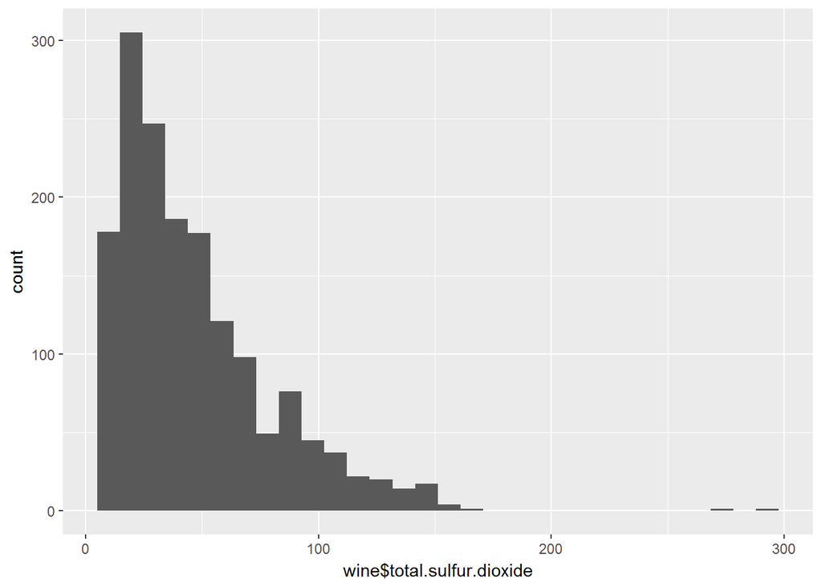

The above plot is positively skewed, We see huge outliers in the plot. Let us normalize this plot.

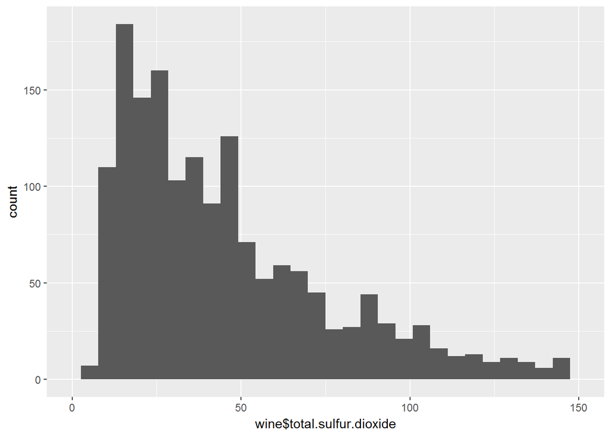

We used scale_x_log10 function to remove outlers, We notice 90% of the observations exist between 11 and 112.10 .

```
##    Min. 1st Qu.  Median    Mean 3rd Qu.    Max.
##   11.00   36.27   61.55   61.55   86.82  112.10
```

## A.7 Free Sulfur Dioxide

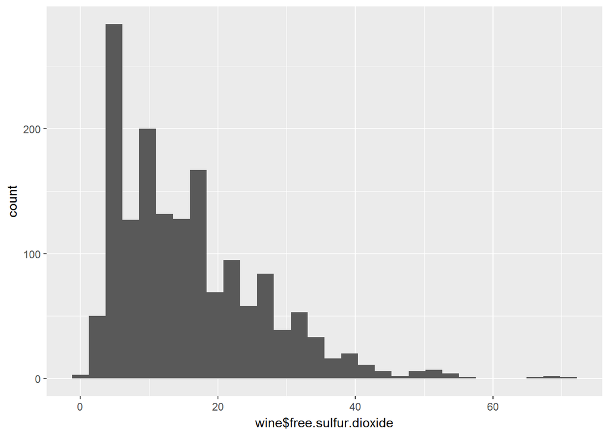

The plot is also positvely skewed, We that 90% percent of observations exist between 4 and 35 in free sulfur dioxide.

```
##    Min. 1st Qu.  Median    Mean 3rd Qu.    Max.
##    4.00   11.75   19.50   19.50   27.25   35.00
```

## A.8 Density

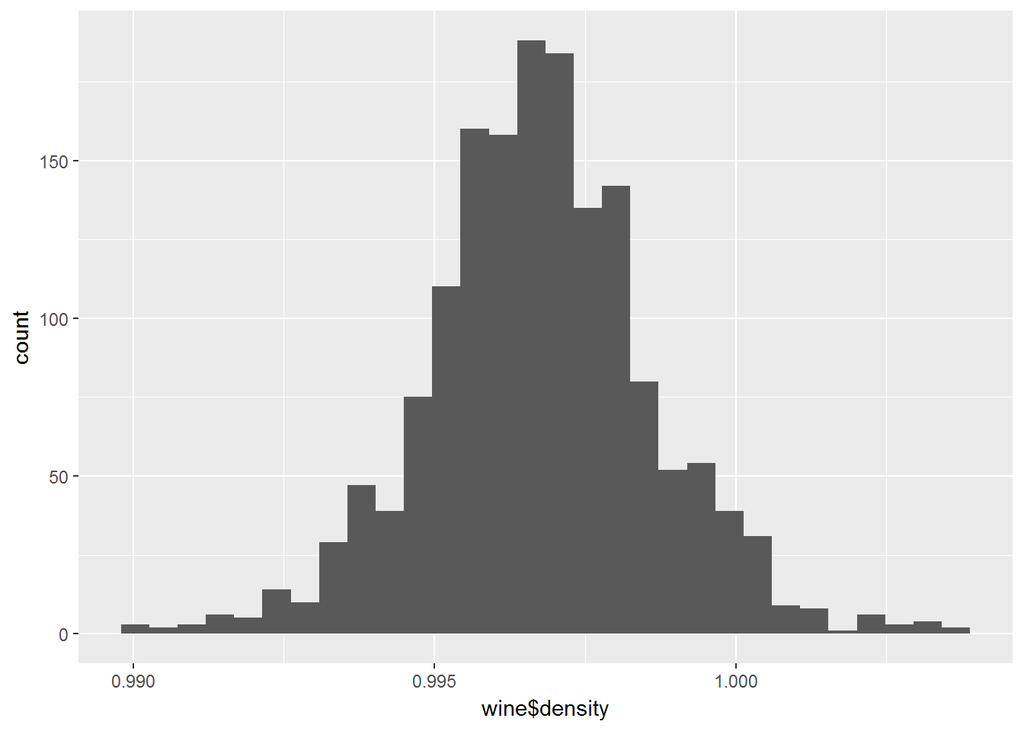

We see a normalized plot for density. We notice from below table that 90% observation ranges between 0.9936 and 1.0000 respectively.

```
##    Min. 1st Qu.  Median    Mean 3rd Qu.    Max.
##  0.9936  0.9952  0.9968  0.9968  0.9984  1.0000
```

## A.9 pH

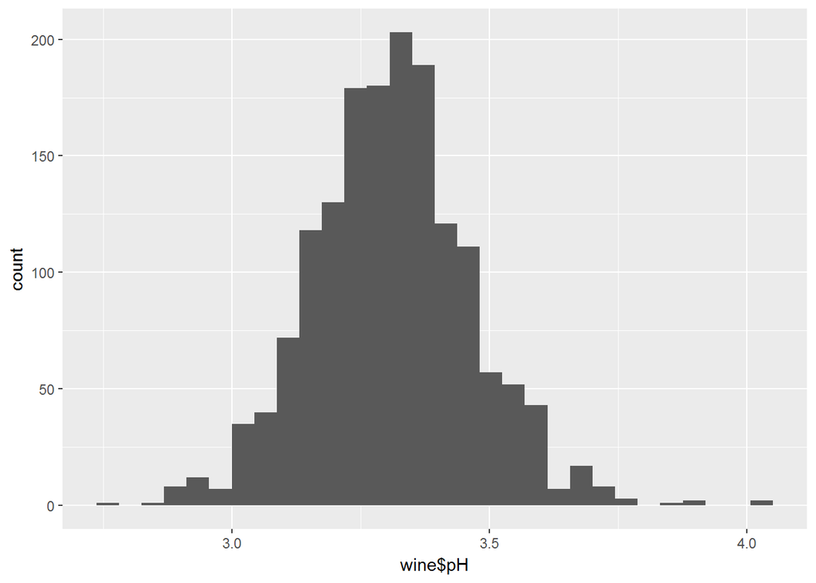

pH value ranges from 2.7 to 4, Where 90% observations exist between 3.06 and 3.57.

```
##    Min. 1st Qu.  Median    Mean 3rd Qu.    Max.
##   3.060   3.188   3.315   3.315   3.442   3.570
```

## A.10 Sulphates

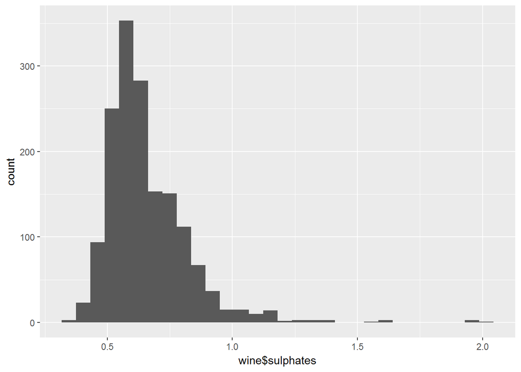

We can see outliers in sulphates. Let us remove these outliers.

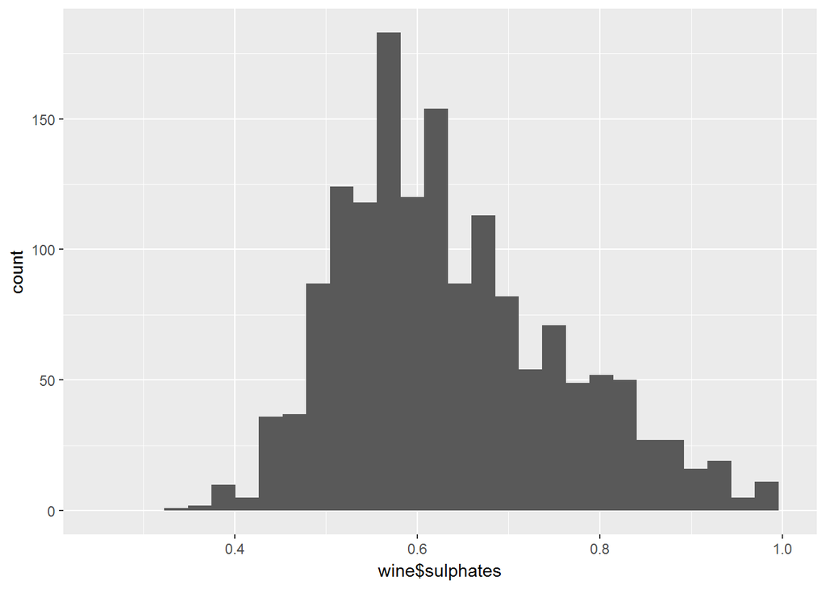

We used Scale_x_log10 function to remove outliers. Sulphate ranges from 0.33 to 2, where 90% observations exist between 0.47 and 0.93.

```
##    Min. 1st Qu.  Median    Mean 3rd Qu.    Max.
##   0.470   0.585   0.700   0.700   0.815   0.930
```

## A.11 Alcohol

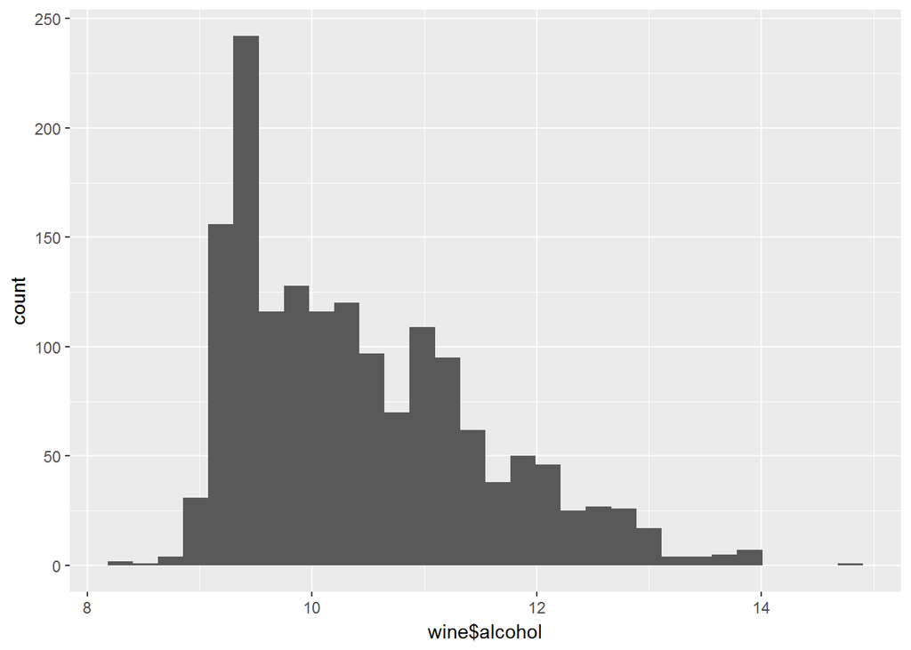

Alcohol ranges from 8.5 to 14.9, where 90% observations exist between 9.2 and 12.5.

```
##    Min. 1st Qu.  Median    Mean 3rd Qu.    Max.
##    9.20   10.02   10.85   10.85   11.68   12.50
```

## A.12 Quality

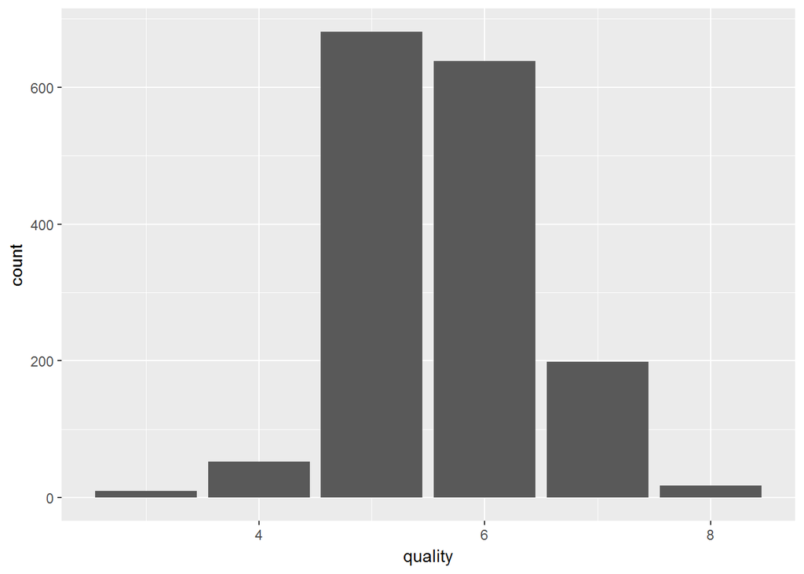

Quality of wine ranges from 3 to 8, Where 90% observations have quality of wine 5, 6 or 7.

```
##    Min. 1st Qu.  Median    Mean 3rd Qu.    Max.
##     5.0     5.5     6.0     6.0     6.5     7.0
```

## Univariate Analysis

### What is/are the main feature(s) of interest in your dataset?

Quality: As quality of the wine is the most important part of the data, We would like to further analyze how each varaible affect quality of the wine.

### What other features in the dataset do you think will help support your investigation into your feature(s) of interest?

1. pH: It is a scale of acidity, It would be interesting to know how each acid variable is related to its PH value.
2. Free Sulfur Dioxide and Total Sulphur Dioxide, how are they related?
3. what relation density has with other varibales.

### Of the features you investigated, were there any unusual distributions? Did you perform any operations on the data to tidy, adjust, or change the form of the data? If so, why did you do this?

1. We found some of the variables positively skewed so we performed scale_x_10 function to normalize some variables.
2. We also noticed that Citric Acid contains 132 values which are 0.
3. Chloride and residual sugar contains a iregular maximum value.
4. Most of the observations are rated 5, 6 or 7 in quality for wine.

# B. Bivariate Plots Section

As Quality of the Wine is the most interesting part of our data set, Let us first explore the relation and effect of each variable with towards the quality of wine. We need to create a new variable for this purpose. We need to make quality integer to factor variable.

## B.1 Corrplot

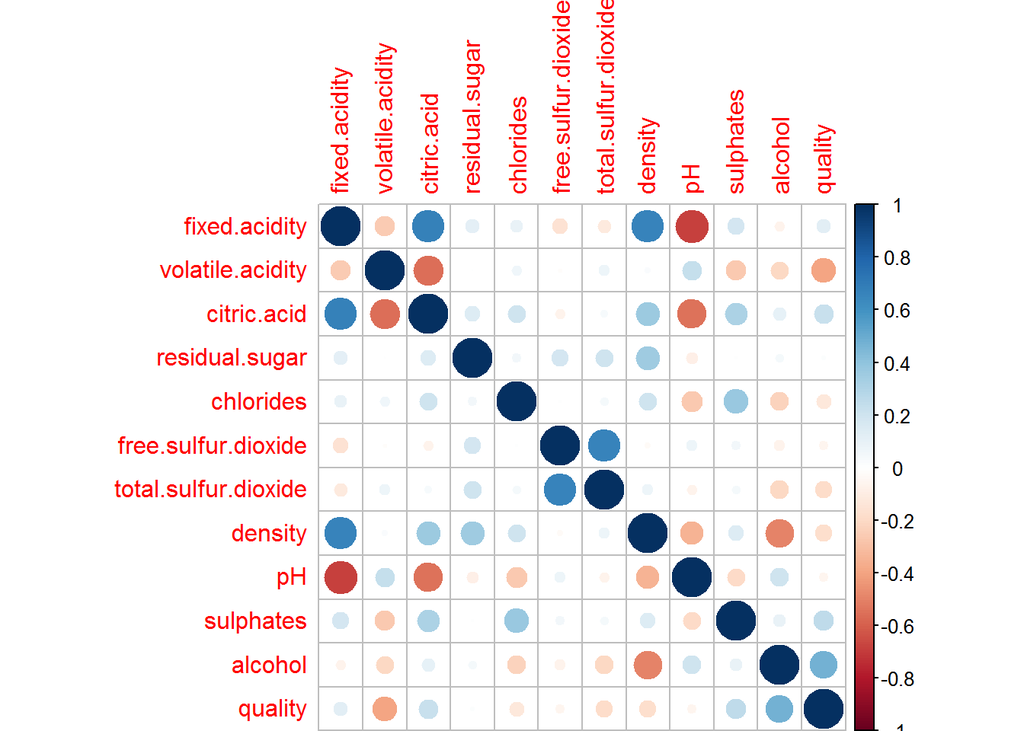

```r
wine_old$X <- NULL

M = cor(wine_old)
corrplot(M)
```

Important relations from corrplot:- 1. Citric Acid and Fixed Acidity 2. Citric Acid vs Volatile Acidity 3. Total Sulfur Dioxide 4. Density and Fixed Acidity 5. pH and Fixed Acidity 6. pH and citric Acid 7. Alcohol and density

As quality is our most important variable, Let us see which variables are related to quality of wine.

Major: Volatile Acidity, Alcohol

Minor: Citric Acid, Sulphates, Density, Total Sulfur dioxide

Others: fixed acidity, chlorides, pH and free sulfur dioxide also show very less correlation.

## B.2 Quality: Major

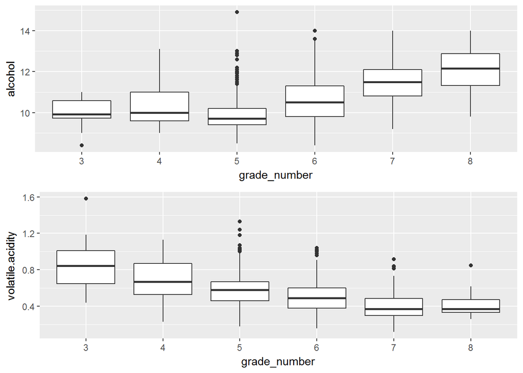

Our earlier observations from corrplot holds true for our major variables. Both show signifcant relation with quality of wine in box plot.

## B.3 Quality: Minor

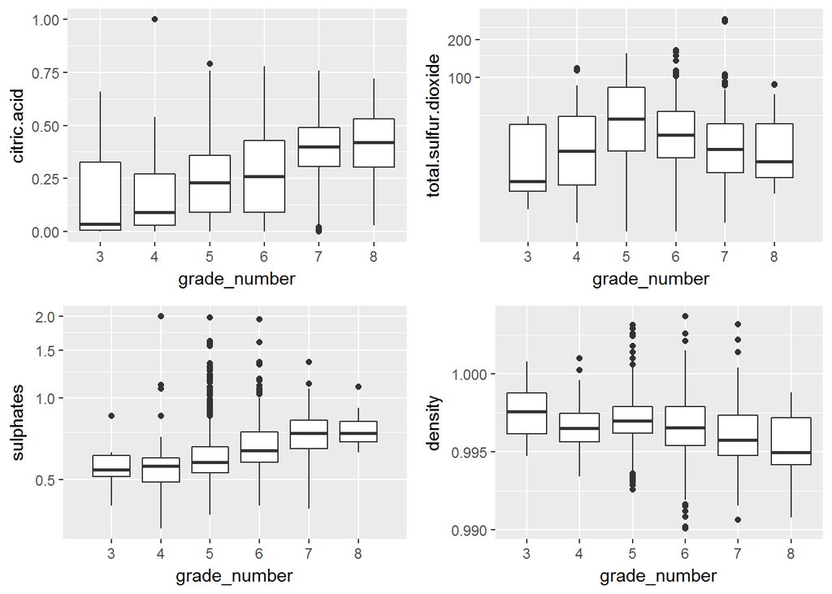

Our earlier observations of minor variables from corrplot holds true with a exception of total sufur dioxide. 1. Citric Acid shows a increasing trend. 2. Total Sulfur dioxide shows no trend. 3. Sulphates also show increasing trend. 4. Density show a decreasing trend.

## B.4 Quality: Others

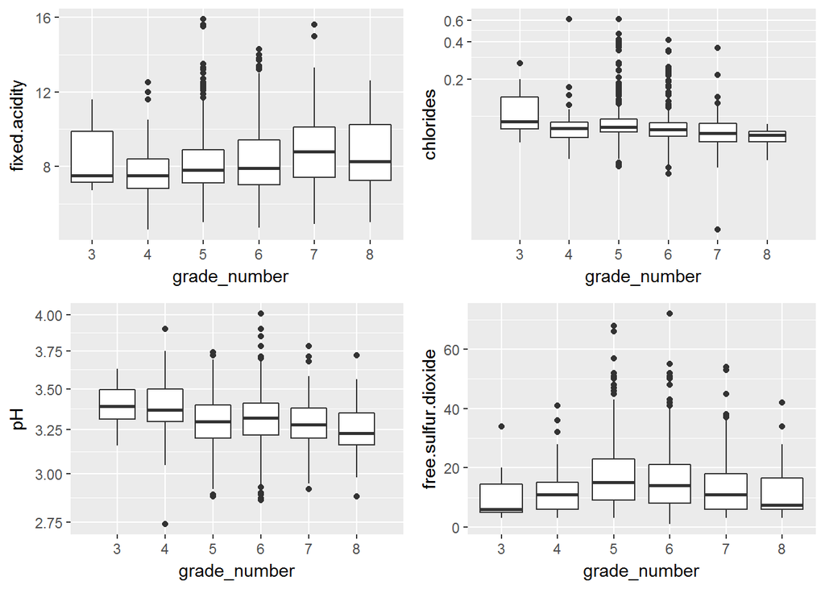

Fixed acidity seems to be consistant with quality of wine. Chloride which is a high variance plot show some trend but it is not very clear. Ph shows trend and needs more exploration. No trend is observed in free sulfur dioxide.

Let us plot pH plot again for conirmation.

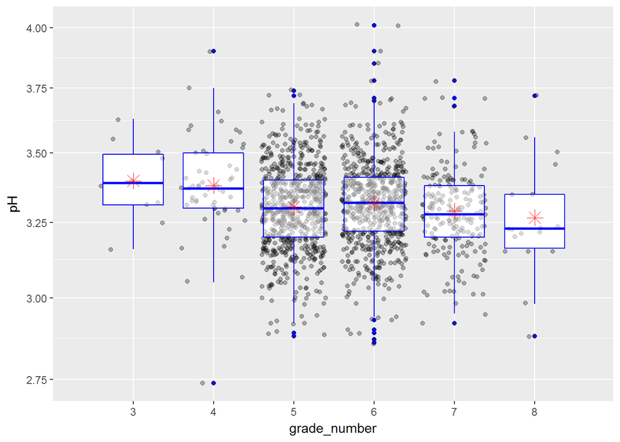

pH shows slight decreasing trend which was not not there in corrplot.

## B.5 Density

### 1.Alcohol

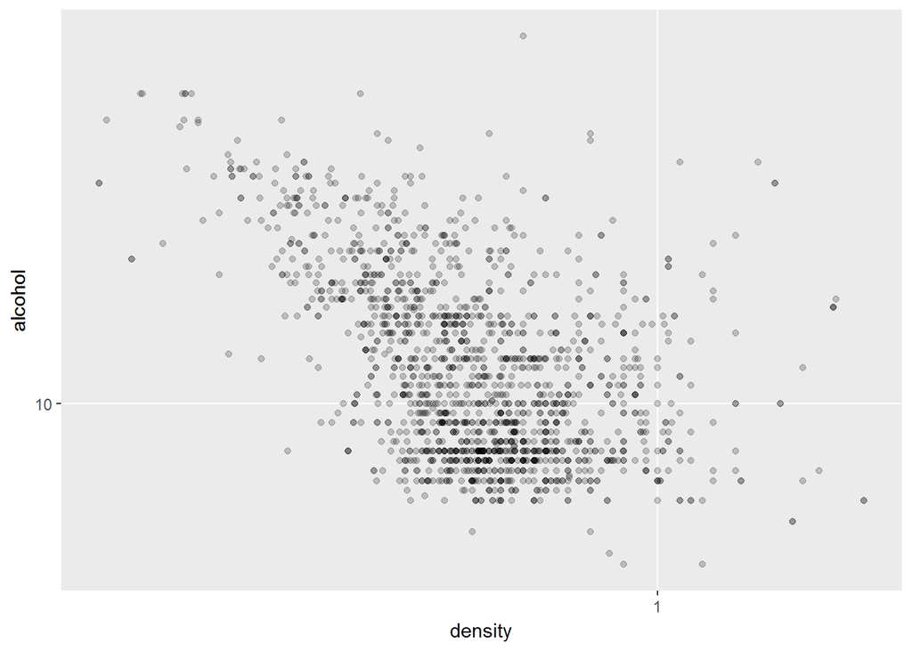

Our earlier observations in corrplot is clearly visible here, We see a trend of decrease in density with increase in alcohol. Below is the correlation value between them.

```r
cor(x = wine$alcohol, y= wine$density)
```

```
## [1] -0.4961798
```

### 2. Fixed Acidity

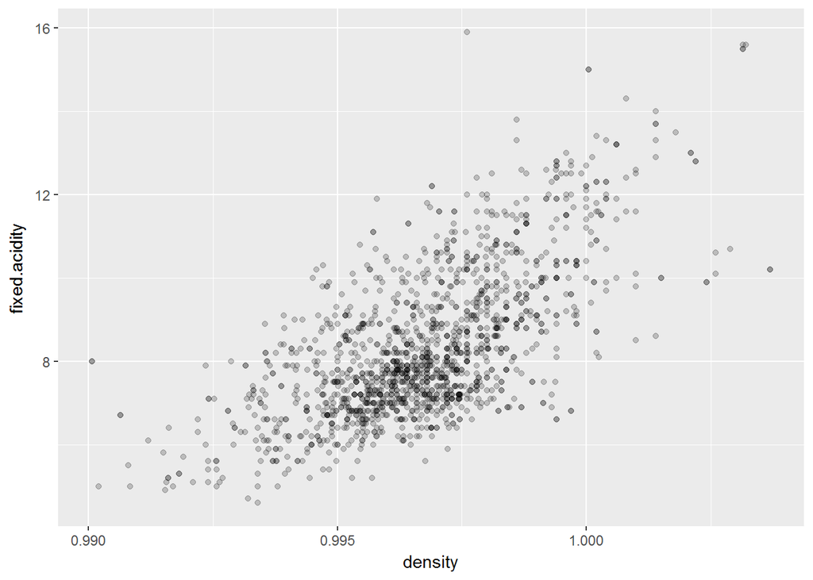

Our earlier observations in corrplot is clearly visible here, We see a trend of increase in density with increase in fixed acidity. Below is the correlation value between them.

```r
cor(y = wine$fixed.acidity, x= wine$density)
```

```
## [1] 0.6680473
```

## B.6 Citric Acid

### 1. Volatile Acidity

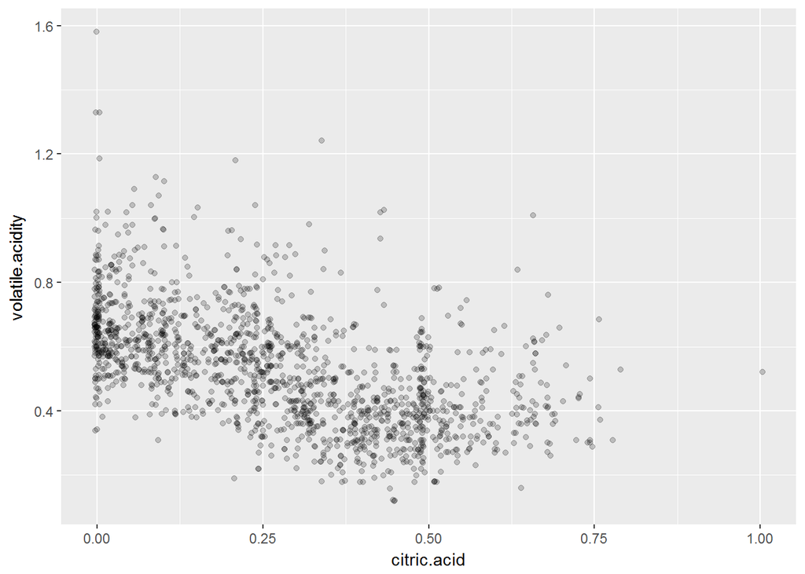

Our earlier observations in corrplot is clearly visible here, We see a trend of decrease in volatile acidity with increase in citric acid. Below is the correlation value between them.

```r
cor(wine$citric.acid, wine$volatile.acidity)
```

```
## [1] -0.5524957
```

### 2.Fixed Acidty

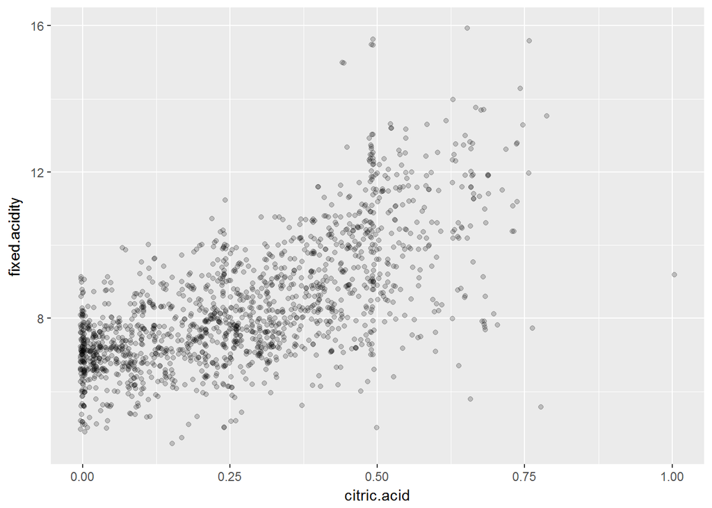

Our earlier observations in corrplot is clearly visible here, We see a trend of increase in fixed acidity with increase in citric acid. Below is the correlation value between them.

```r
cor(wine$citric.acid, wine$fixed.acidity)
```

```
## [1] 0.6717034
```

We notice how citric acid increase with increase in fixed acidity and decrease with increase in volatile acidity.

## B.7 Total sulfur dioxide vs Free sulfur dioxide

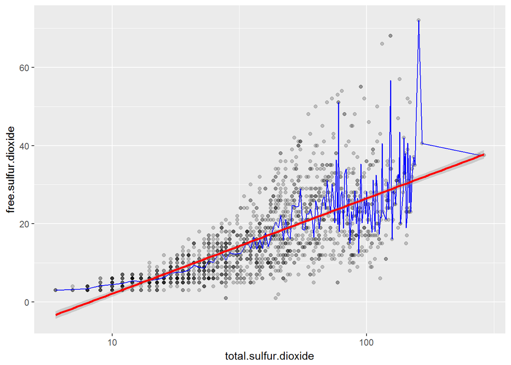

we notice a clear trend of increase in total sulfur dioxide with increase in free sulfur dioxide. Here is the correlation value between them

```r
cor(wine$total.sulfur.dioxide, wine$free.sulfur.dioxide)
```

```
## [1] 0.6676665
```

## B.8 pH

We plot the relations we observed in corrplot of pH.

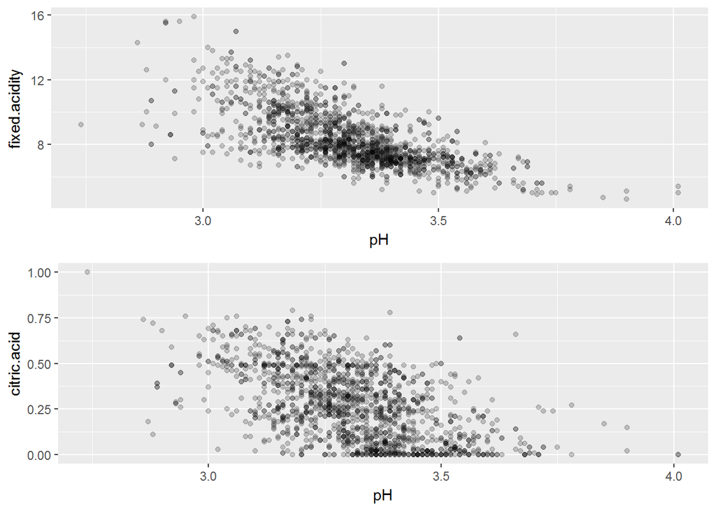

we see a clear trend of increase in pH value with decrease in fixed acidity and citric acid.

# Bivariate Analysis

### Did you create any new variables from existing variables in the dataset?

We created a new variable called ‘grade_number’ from the quality variable, This made the a functional variable from a numerical variable which helped us generate multiple bivariate plots.

### How did the feature(s) of interest vary with other features in the dataset?

As quality being the main feature of our data set, We checked relation of each variable with quality, Our preliminary analysis state this about quality

1. Quality of wine increases with increase in Alcohol content.
2. Quality of wine increases with decrease in Volatile Acidity.
3. Quality of wine increases with decrease in its density.
4. Quality of wine increases with increase in Citric Acid.
5. Quality of wine increases with increase in Sulphates
6. Quality of wine increases with decrease in pH value.

### Did you observe any interesting relationships between the other features ?

1. pH value decrease with increase in fixed acidity and citric acid.
2. Density of wine increases with decrease in alcohol content and increases with increase in fixed acidity.

# C. Multivariate Plots Section

## C.1 Quality

As alcohol is a significant factor for determining quality of wine, Let us plot other major and minor variables with alcohol to find other important plots.

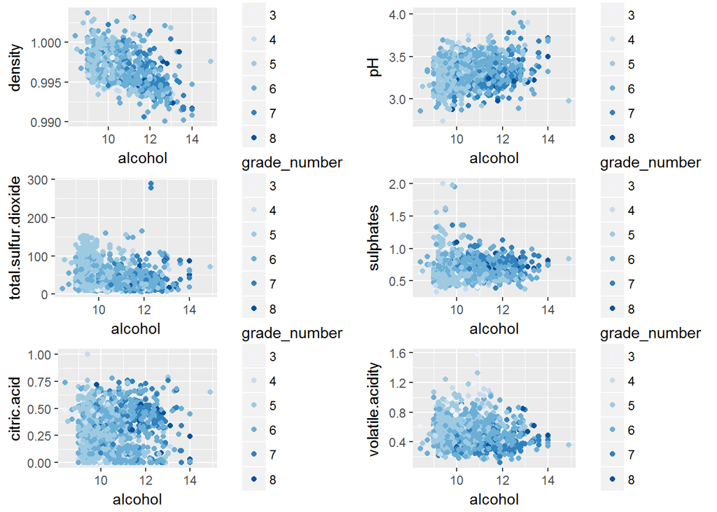

Plot of (volatile acidity vs alcohol) and (sulphates vs alcohol) shows the most signifcant relation in grid arrange. Let us plot them again.

### 1. (volatile acidity vs alcohol)

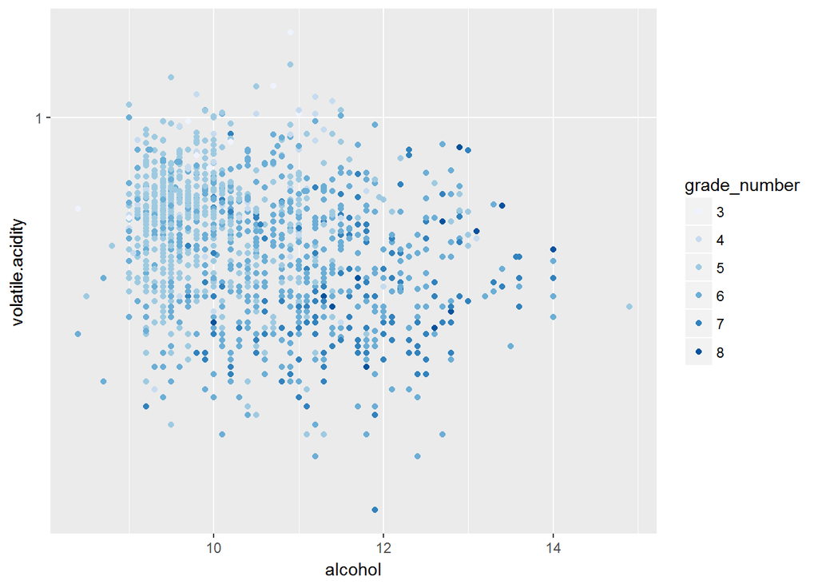

Volatile acidity and Alcohol are 2 major factor in determining quality of wine. In above plot when we keep the alcohol constant and increase the volatile acidity we see decrease in quality of wine.

### 2. (sulphates vs alcohol)

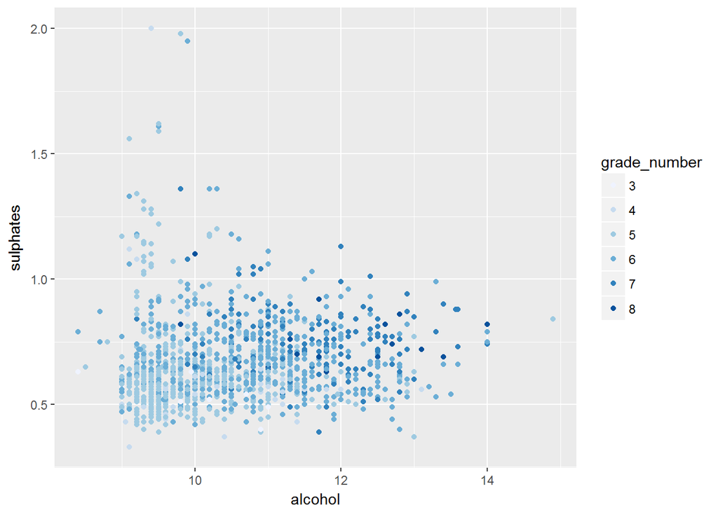

Although sulphate was a minor variable in our corrplot, We observe how sulphate vs alcohol plot is most visual and showing a clear trend. We can see how when we keep the alcohol constant increase sulphates, we see increase in quality of wine.